# Visualization

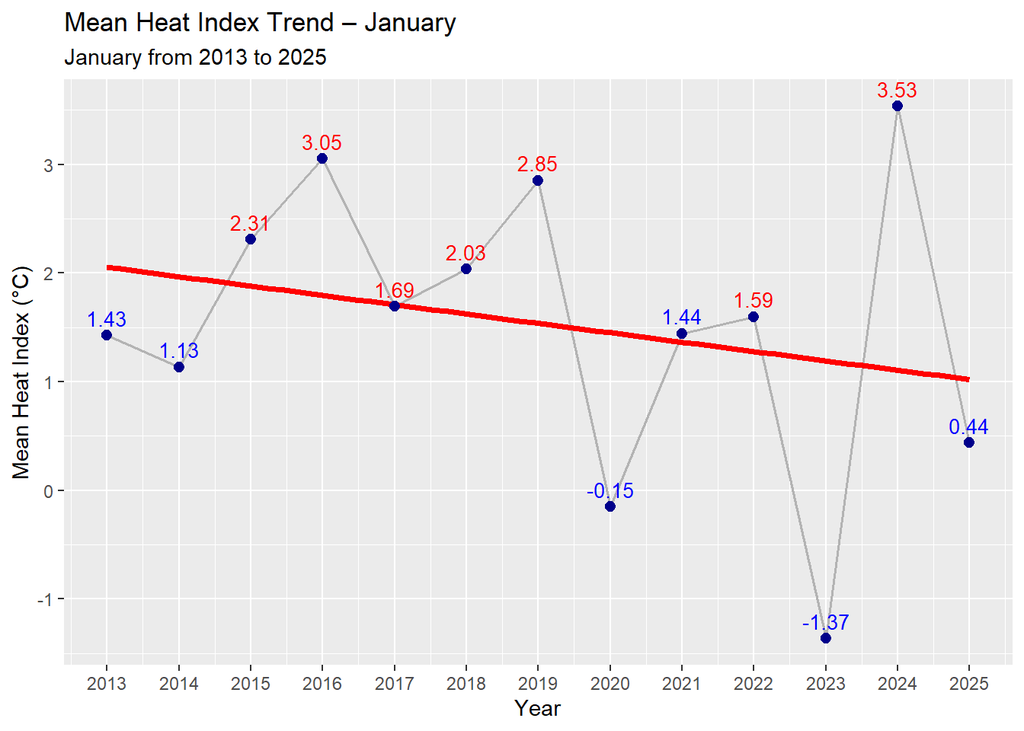

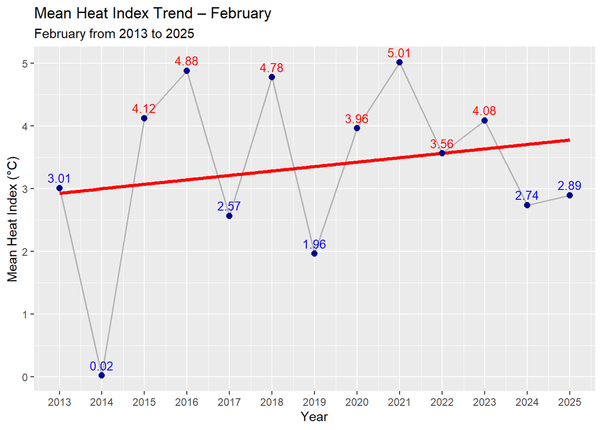

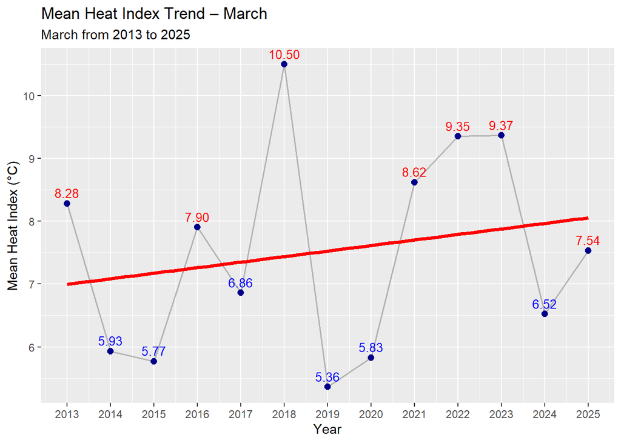

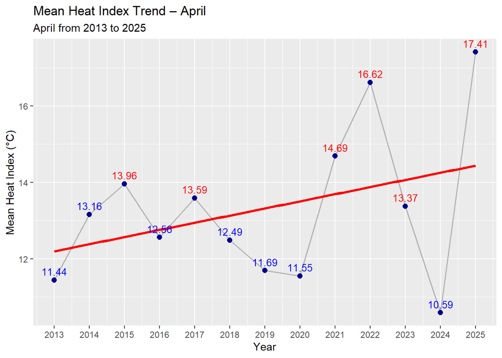

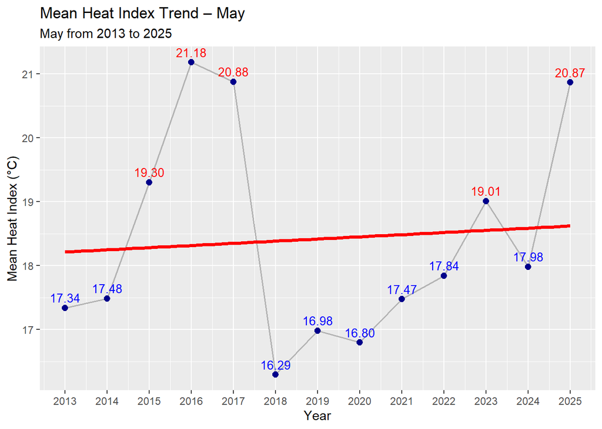

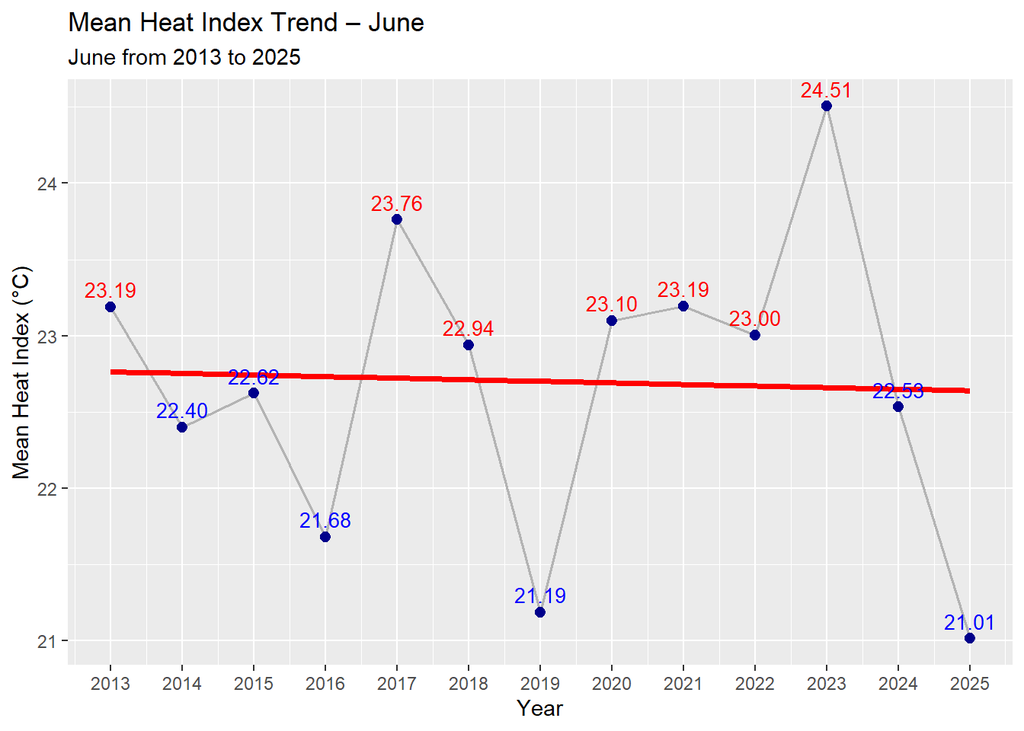

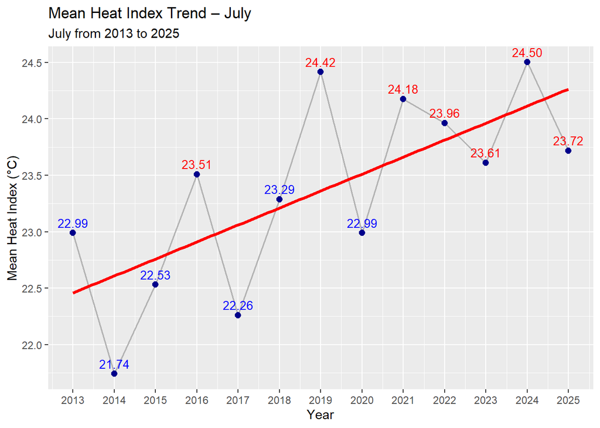

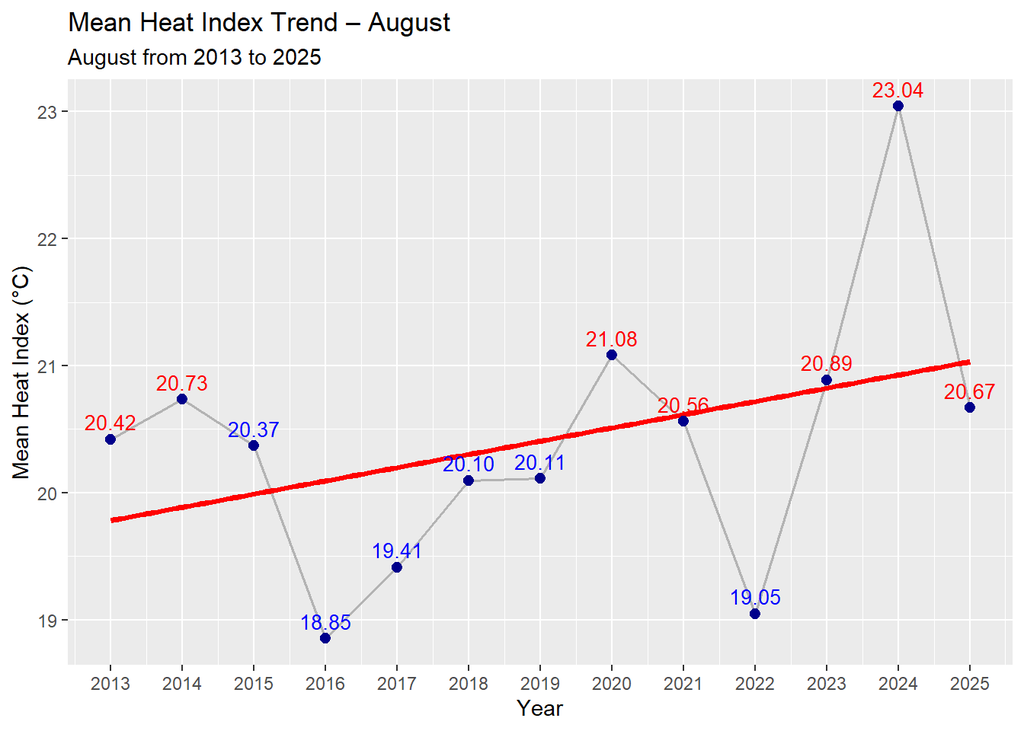

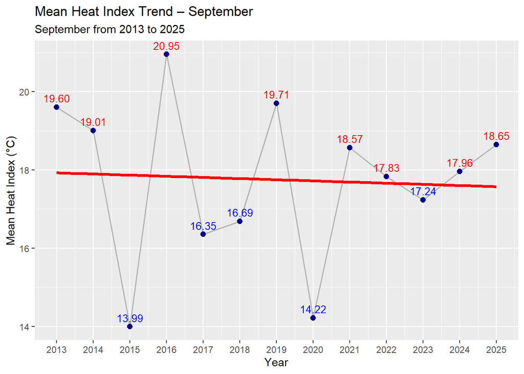

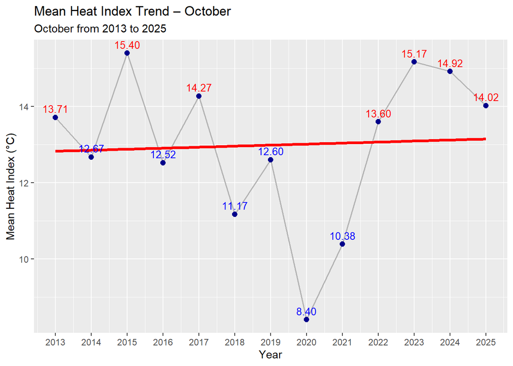

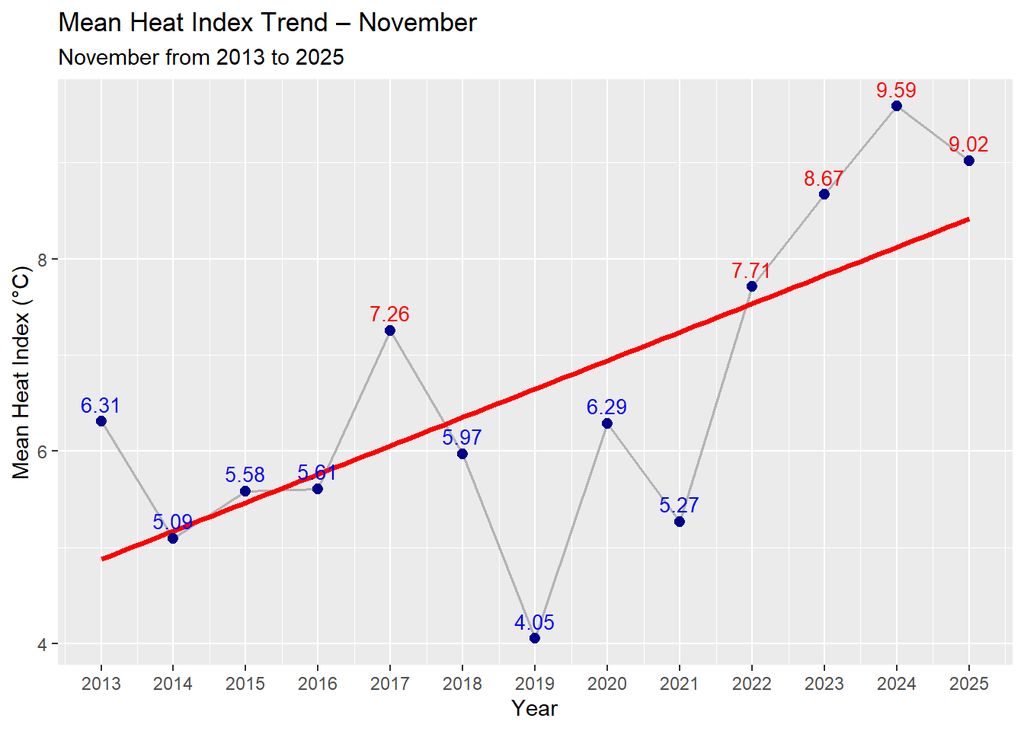

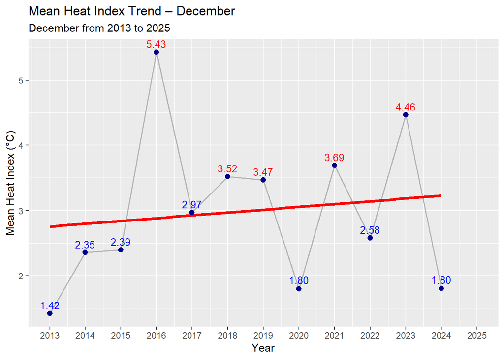

```r
data <- tibble()
plots <- c()
all_years <- levels(as.factor(my_data$year))

for (month in 1:12) {
  temp_data <- tibble()
  for (year in all_years) {
    start_date <- ymd(paste0(year, "-", month, "-", "01"))
    end_date <- ceiling_date(start_date, "month") - days(1)

    period <- my_data %>% filter(full_date >= start_date & full_date <= end_date)

    mean_temperature <- mean(period$temp_air_mean_c, na.rm = TRUE)
    mean_heat_index <- mean(period$HI_standard, na.rm = TRUE)

    temp_data <- rbind(temp_data, tibble(year=year(start_date), month=month(start_date), mean_temperature=mean_temperature, mean_heat_index=mean_heat_index))
  }

  the_plot = temp_data %>% ggplot() +
geom_line(aes(x = year, y = mean_heat_index), color = "grey70", linewidth = 0.6) +
geom_smooth(
  aes(x = year, y = mean_heat_index),
  method = "lm",
  se = FALSE,
  color = "red", linewidth = 1.3, linetype = "solid"
) +
geom_point(aes(x = year, y = mean_heat_index), color = "darkblue", size = 2.2) +
labs(x = "Year", y = "Mean Heat Index (°C)",
         title = paste0("Mean Heat Index Trend – ", month.name[month]),
         subtitle = paste0(month.name[month], " from ", min(all_years), " to ", max(all_years))) +
    scale_x_continuous(
    breaks = seq(min(temp_data$year), max(temp_data$year), by = 1),
    labels = function(x) floor(x)
  ) +
geom_text(
  aes(
    x = year,
    y = mean_heat_index,
    label = sprintf("%.2f", mean_heat_index),
    color = mean_heat_index > mean(mean_heat_index, na.rm = TRUE)
  ),
  vjust = -0.6,
  size = 3.5
) +
scale_color_manual(values = c("blue", "red"), guide = "none")
  plots <- c(plots, the_plot)

  data <- rbind(data, temp_data)
}
plots
```

## Statistical trend summary per month

I fit linear regression models and perform Mann–Kendall trend tests on monthly mean Heat Index values to assess the direction, magnitude, and statistical significance of long-term trends.

```r
analyze_trend <- function(df_month) {

  # Early exit if too few years → regression not meaningful
  if (nrow(df_month) < 3) {
    return(tibble(
      month = unique(df_month$month),
      note  = "Fewer than 3 years of data"
    ))
  }

  # Linear model: temperature ~ year
  model <- lm(mean_heat_index ~ year, data = df_month)

  slope     <- coef(model)[2]
  p_value   <- glance(model)$p.value
  r_squared <- glance(model)$r.squared
  years     <- max(df_month$year) - min(df_month$year) + 1
  total_change <- slope * (years - 1)

  # Non-parametric trend test
  mk_test <- MannKendall(df_month$mean_heat_index)

  # Decide trend category using both parametric (lm) and non-parametric (MK) results
  trend_type <- case_when(
    p_value > 0.05 & mk_test$sl > 0.05   ~ "No significant trend",
    slope > 0   & mk_test$sl <= 0.05     ~ "Significant increasing trend",
    slope < 0   & mk_test$sl <= 0.05     ~ "Significant decreasing trend",
    TRUE                                 ~ "Weak or oscillating trend"
  )

  # Return summary row
  tibble(
    month          = unique(df_month$month),
    slope_per_year = round(slope, 4),
    total_change   = round(total_change, 2),
    lm_p           = round(p_value, 4),
    mk_p           = round(mk_test$sl, 4),
    mk_tau         = round(mk_test$tau, 3),
    trend          = trend_type
  )
}

trend_summary <- data %>%
  group_by(month) %>%
  group_split() %>%
  map_dfr(analyze_trend) %>%
  arrange(month)

print(trend_summary)
```

```
## # A tibble: 12 × 7
##    month slope_per_year total_change   lm_p  mk_p mk_tau trend
##    <dbl>          <dbl>        <dbl>  <dbl> <dbl>  <dbl> <chr>
##  1     1        -0.0861        -1.03 0.410  0.669 -0.103 No significant trend
##  2     2         0.0708         0.85 0.514  0.951  0.026 No significant trend
##  3     3         0.0881         1.06 0.491  0.502  0.154 No significant trend
##  4     4         0.187          2.24 0.222  0.502  0.154 No significant trend
##  5     5         0.0338         0.41 0.798  0.502  0.154 No significant trend
##  6     6        -0.0103        -0.12 0.894  0.951 -0.026 No significant trend
##  7     7         0.150          1.81 0.008  0.024  0.487 Significant increasing…
##  8     8         0.104          1.25 0.193  0.246  0.256 No significant trend
##  9     9        -0.0295        -0.35 0.856  0.951 -0.026 No significant trend
## 10    10         0.0267         0.32 0.868  0.951  0.026 No significant trend
## 11    11         0.295          3.54 0.0098 0.024  0.487 Significant increasing…
## 12    12         0.043          0.52 0.684  0.373  0.212 No significant trend
```

- month: Calendar month (1–12) analyzed.
- slope_per_year: Estimated annual change in monthly mean Heat Index (°C/year).
- total_change: Estimated cumulative change over the study period.
- lm_p: P-value from the linear regression model.
- mk_p: P-value from the Mann–Kendall trend test.
- mk_tau: Kendall’s Tau coefficient indicating trend direction and strength.
- trend: Qualitative interpretation based on both statistical tests.

## Extreme temperature days by month (hot vs cold)

I identify days with extreme heat or cold (previously defined as values exceeding the 30-day rolling mean ± 2 standard deviations) and summarize their monthly distribution across the entire study period.

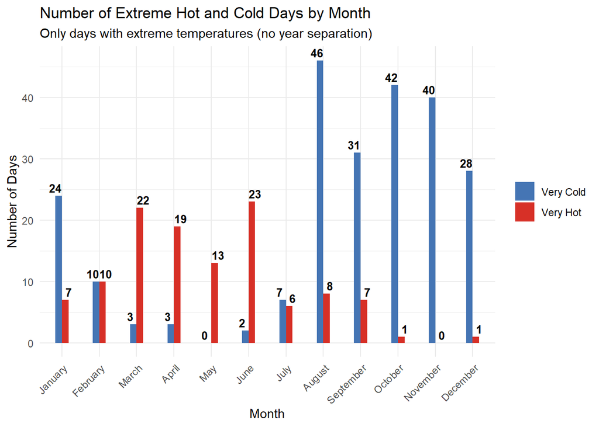

```r
extreme_temperature_days <- my_data %>%
  filter(is_extreme_hot == TRUE | is_extreme_cold == TRUE)

result_wide <- extreme_temperature_days %>%
  mutate(
    month_name = month(full_date, label = TRUE, abbr = FALSE)
  ) %>%
  group_by(month_name) %>%
  summarise(
    very_hot  = sum(is_extreme_hot,  na.rm = TRUE),
    very_cold = sum(is_extreme_cold, na.rm = TRUE),
    .groups = "drop"
  ) %>%
  mutate(
    month_name = factor(month_name, levels = month.name)
  )

  result_long <- result_wide %>%
    pivot_longer(
      cols = c(very_hot, very_cold),
      names_to = "temperature_type",
      values_to = "count"
    )

ggplot(result_long, aes(x = month_name, y = count, fill = temperature_type)) +

  geom_col(position = position_dodge(width = 0.35), width = 0.35) +

  geom_text(
    aes(
      label = count,
      y = count
    ),
    position = position_dodge(width = 0.70),
    vjust = -0.4,
    size = 3.4,
    fontface = "bold",
    color = "black"
  ) +

  scale_fill_manual(
    values = c("very_hot"   = "#d73027",
               "very_cold" = "#4575b4"),
    labels = c("very_hot"   = "Very Hot",
               "very_cold" = "Very Cold")
  ) +

  scale_x_discrete(name = "Month") +

  labs(
    y = "Number of Days",
    title = "Number of Extreme Hot and Cold Days by Month",
    subtitle = "Only days with extreme temperatures (no year separation)",
    fill = NULL
  ) +

  theme_minimal() +
  theme(axis.text.x = element_text(angle = 45, hjust = 1))
```

## Extreme temperature occurrence during Ramadan

- **Percentage of extreme temperature days within Ramadan**  
  (Number of extreme days during Ramadan ÷ Total number of Ramadan days across the period)  
  This ratio summarizes how frequently extreme temperature events occurred during Ramadan throughout the study period.
- **Year-by-year comparison of extreme days**  
  A bar chart compares the total number of extreme days in each full year against the number of extreme days occurring only during Ramadan in the same year. This helps visualize whether Ramadan periods contributed disproportionately to annual extremes in specific years.

#### Calculate percentage of extreme days during Ramadan (full period)

This code computes the overall proportion of Ramadan days that were classified as extreme.

```r
extreme_temperature_ramadan_days <- my_data %>%
  filter(is_ramadan == TRUE & (is_extreme_hot == TRUE | is_extreme_cold == TRUE))

ramadan_days_total <- my_data %>% filter(is_ramadan == TRUE)

ramadan_extreme_ratio <- nrow(extreme_temperature_ramadan_days) / nrow(ramadan_days_total)

print(paste("Percentage of extreme days during Ramadan:", round(ramadan_extreme_ratio * 100, 1), "%"))
```

```
## [1] "Percentage of extreme days during Ramadan: 4.9 %"
```

## Year-by-year comparison: Extreme days in Ramadan vs. full year

This bar chart shows, for each year, the total number of extreme temperature days in the entire year versus the subset that occurred during Ramadan. This comparison helps determine whether extreme temperature events were disproportionately concentrated within Ramadan in particular years.

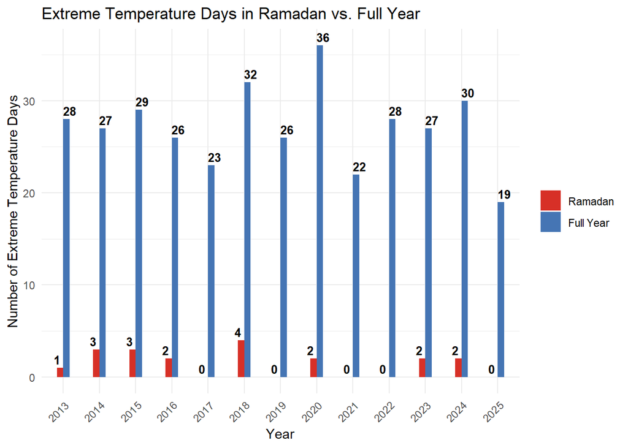

```r
yearly_summary <- my_data %>%
  mutate(year = year(full_date)) %>%
  group_by(year) %>%
  summarise(
    total_extreme = sum(is_extreme_hot | is_extreme_cold, na.rm = TRUE),
    ramadan_extreme = sum((is_extreme_hot | is_extreme_cold) & is_ramadan, na.rm = TRUE),
    .groups = "drop"
  ) %>%
  pivot_longer(cols = c(total_extreme, ramadan_extreme),
               names_to = "type",
               values_to = "count")

ggplot(yearly_summary, aes(x = as.factor(year), y = count, fill = type)) +
  geom_col(position = position_dodge(width = 0.35), width = 0.35) +
  geom_text(
    aes(
      label = count,
      y = count
    ),
    position = position_dodge(width = 0.70),
    vjust = -0.4,
    size = 3.4,
    fontface = "bold",
    color = "black"
  ) +
  scale_fill_manual(
    values = c("total_extreme"   = "#4575b4",
               "ramadan_extreme" = "#d73027"),
    labels = c("total_extreme"   = "Full Year",
               "ramadan_extreme" = "Ramadan")
  ) +
  labs(
    x = "Year",
    y = "Number of Extreme Temperature Days",
    title = "Extreme Temperature Days in Ramadan vs. Full Year",
    fill = NULL
  ) +
  theme_minimal() +
  theme(axis.text.x = element_text(angle = 45, hjust = 1))
```